# Visualisation et analyse de données de biologie végétale

Océane Cassan - oceane.cassan@cnrs.fr

09/01/2021

# Contexte

Ce document est une proposition de solution pour la session pratique d’introduction à la rédaction de rapports d’analyse sous Rmarkdown. Il s’agit du document final, sensé être obtenu après avoir suivi les directives du sujet.

Les données analysées sont issues d’un [publication](https://nph.onlinelibrary.wiley.com/doi/10.1111/nph.13799) intitulée “Fluctuating, warm temperatures decrease the effect of a key floral repressor on flowering time in Arabidopsis thaliana” de 2015 (Burghardt et al. 2015)

Dans ces données, plusieurs génotypes d’Arabidopsis thaliana, une plante modèle, ont été phénotypés (leurs caractéristiques morphologiques, leur réponse à l’environnement, ont été mesurés).

# Import des données

On dispose de données liées à la floraison et aux phénotypes des parties aériennes de plantes de différents génotypes. Les fichier csv des données biologiques à étudier est importé et ses premières lignes peuvent être inspectées via la fonction `head` :

```r
data <- read.csv("data/burghardt_et_al_2015_expt1.csv")
dim(data)
```

```
## [1] 957  15
```

```r
head(data)
```

```
##   genotype background temperature fluctuation day.length vernalization
## 1  Col Ama        Col          12         Con         16            NV
## 2  Col Ama        Col          12         Con         16            NV
## 3  Col Ama        Col          12         Con         16            NV
## 4  Col Ama        Col          12         Con         16            NV
## 5  Col Ama        Col          12         Con         16            NV
## 6  Col Ama        Col          12         Con         16            NV
##   survival.bolt bolt days.to.bolt days.to.flower rosette.leaf.num
## 1             Y    Y           28             43               18
## 2             Y    Y           29             44               15
## 3             Y    Y           31             43               13
## 4             Y    Y           31             42               17
## 5             Y    Y           32             44               19
## 6             Y    Y           33             47               14
##   cauline.leaf.num blade.length.mm total.leaf.length.mm blade.ratio
## 1                6            12.9                 21.1   0.6113744
## 2                5            10.5                 19.1   0.5497382
## 3                4            13.2                 23.4   0.5641026
## 4                5            14.6                 27.2   0.5367647
## 5                4            13.3                 20.4   0.6519608
## 6                4            14.7                 25.3   0.5810277
```

# Visualisation

## Visualisation simple

On affiche le nombre de jours jusqu’à floraison pour les différents génotypes, durée de jours, et la température de culture :

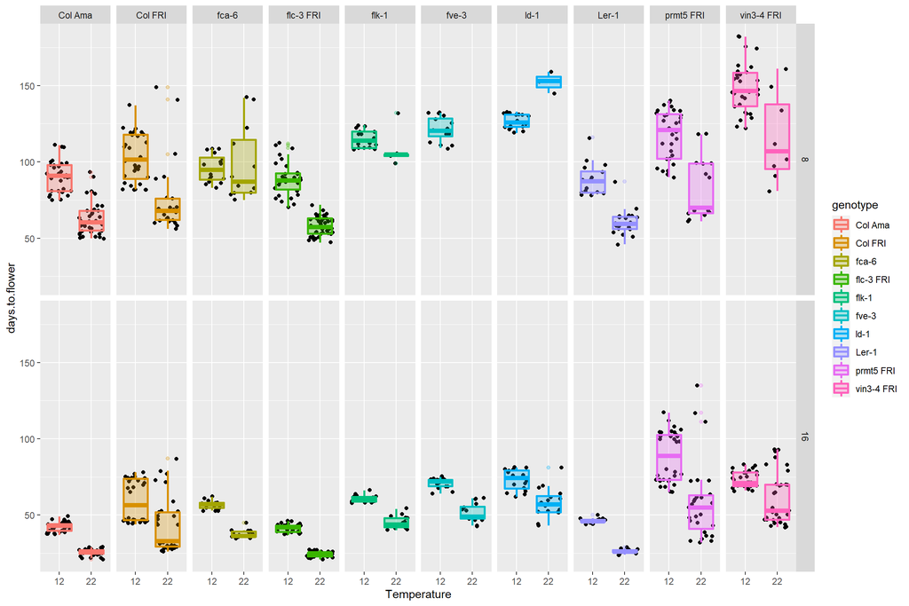

```r
data$temperature <- factor(data$temperature)
data$day.length = factor(data$day.length)

ggplot(data, aes(x = factor(temperature),
                 y = days.to.flower,
                 color = genotype )) +
  geom_jitter(color = "black")+
  geom_boxplot(aes(fill = genotype), alpha = 0.3, size = 1) +
  facet_grid(day.length~genotype) +
  xlab("Temperature")
```

On constate qu’une température plus élevée aura tendance à diminuer le temps nécessaire à la floraison. La durée du jour est également influente, car on voit que des jours longs feront fleurir plus vite les plantes.

## Tests statistiques sur les visualisations

Il s’agit ici de reproduire le même graphe mais en se demandant si les durées jusqu’à floraison sont significativement impactées par la température. La fonction `stat_compare_means` du package `ggpubr` permet de rajouter un test de comparaison de moyennes (ici non paramétrqie, le wilcox.test)

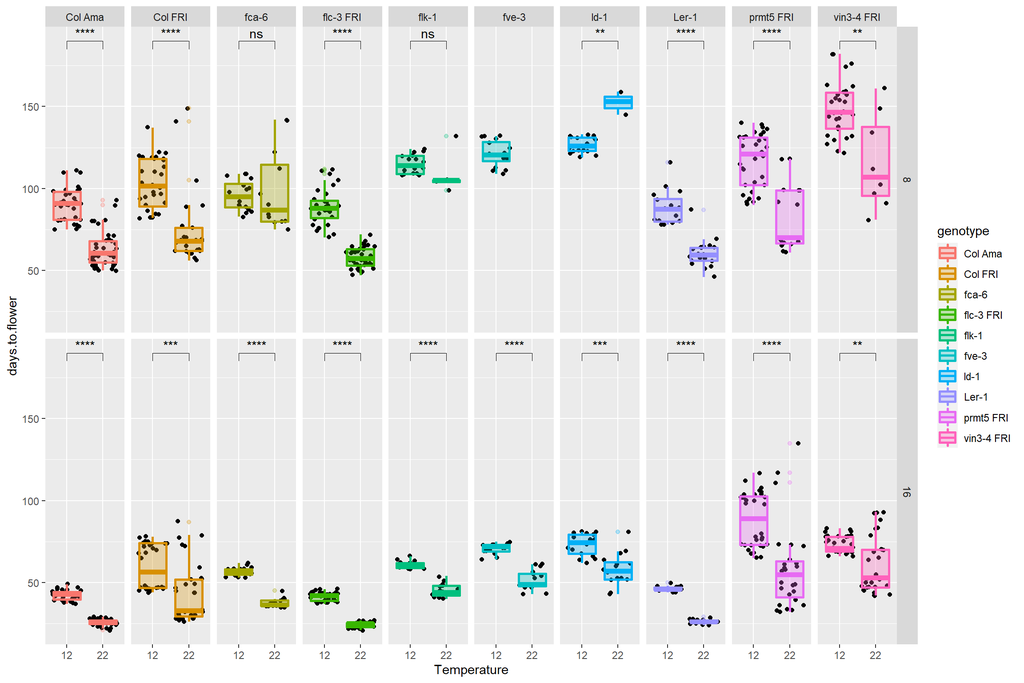

```r
comparisons <- list(c("12", "22"))
ggplot(data, aes(x = temperature,
                 y = days.to.flower,
                 color = genotype )) +
  geom_jitter(color = "black")+
  geom_boxplot(aes(fill = genotype), alpha = 0.3, size = 1) +
  facet_grid(day.length~genotype) +
  xlab("Temperature") +
  stat_compare_means(comparisons = comparisons, label = "p.signif")
```

# Régression linéaire

Tout d’abord, on affiche la relation entre le nombre de feuilles et le temps jusqu’à floraison. On distingue les observations réalisées en jours courts ou en jours longs par la couleur :

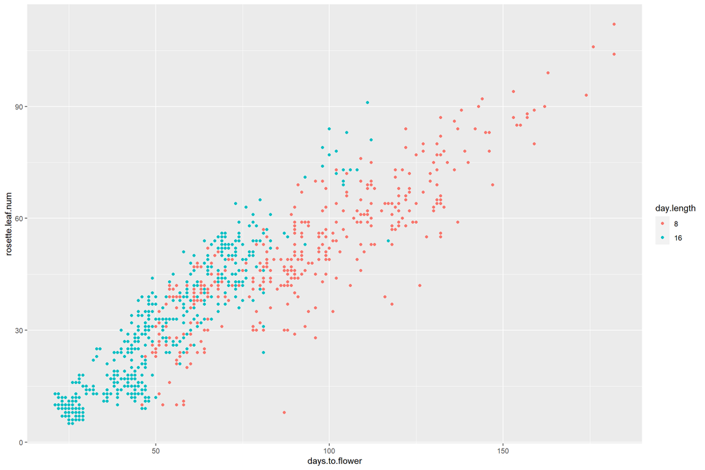

```r
ggplot(data, aes(x = days.to.flower,
                 y = rosette.leaf.num,
                 color = day.length)) + geom_point()
```

On va expliquer le nombre de feuilles d’une plante au moyen du temps qu’elle a mis a fleurir, et de la longueur des jours lors de la culture (en ajoutant un terme d’interaction).

```r
lm <- lm(data = data, rosette.leaf.num~days.to.flower*day.length)
extract_eq(lm)
```

$$\operatorname{rosette.leaf.num} = \alpha + \beta_{1}(\operatorname{days.to.flower}) + \beta_{2}(\operatorname{day.length}_{\operatorname{16}}) + \beta_{3}(\operatorname{days.to.flower} \times \operatorname{day.length}_{\operatorname{16}}) + \epsilon$$

```r
prettify(summary(lm))
```

```
##                                  Estimate  CI (lower)  CI (upper) Std. Error
## 1                 (Intercept)   2.0202608  -0.5751267   4.6156482 1.32232708
## 2              days.to.flower   0.5284896   0.5018715   0.5551077 0.01356169
## 3              day.length: 16 -14.2683652 -17.5126386 -11.0240919 1.65292871
## 4 days.to.flower:day.length16   0.2932376   0.2491149   0.3373603 0.02248013
##     t value Pr(>|t|)
## 1  1.527807    0.127
## 2 38.969314   <0.001 ***
## 3 -8.632172   <0.001 ***
## 4 13.044297   <0.001 ***
```

Pour nous assurer que le modèle linéaire est correct et interprétable, nous inspectons ses résidus :

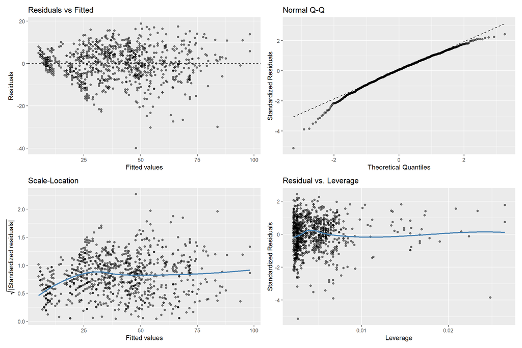

```r
gglm(lm)
```

Ce que l’on peut conclure des résultats du modèle linéaire :

- Effet positif significatif du temps jusqu’à floraison sur le nombre de feuilles : augmenter ce temps de une unité fait augmenter le nombre de feuille de 0.53. (pour le niveau référence de la langueur de jour)
- Effet négatif significatif de l’allongement du jour : pour le niveau référence du temps de floraison, passer de 8j à 16j de culture diminue le nombre moyen de feuilles de 14 environ.
- L’interaction positive est significative : il y a un changement de pente entre la droite de régression sur la durée de floraison, suivant que les jours soient longs ou courts. A 16 jours, la nombre de feuilles augmente plus fortement sous l’effet du temps jusqu’à floraison qu’ à 8j.

# References

Burghardt, Liana T., Daniel E. Runcie, Amity M. Wilczek, Martha D. Cooper, Judith L. Roe, Stephen M. Welch, and Johanna Schmitt. 2015. “Fluctuating, Warm Temperatures Decrease the Effect of a Key Floral Repressor on Flowering Time in Arabidopsis Thaliana.” *New Phytologist* 210 (2): 564–76. https://doi.org/10.1111/nph.13799.

A work by [Océane Cassan](https://github.com/OceaneCsn/)

*oceane.cassan@cnrs.fr*